# Getting started with flexdashboard

15 May 2018

## Introduction

This session will cover how to get started building flexdashboard. It builds on the R markdown session in April 2018, available [here](https://educationgovuk.sharepoint.com/sites/sarpi/g/AC/Coffee%20and%20Coding.aspx)

A flexdashboard is created using R Markdown and allows you to create interactive and visually appealing dashboard easily.

A complementary getting started guide is [here](https://rmarkdown.rstudio.com/flexdashboard/)

## Why use a flexdashboard

- They are relatively simple to build
- They provide a level of interactivity with html widgets
- They look good
- You don't need Shiny! (but you can use it)

## Requirements

To build a flexdashboard you will need to install the following from the software centre:

- R version 3.4.2
- R Studio 1.1.383

You will also need:

- The flexdashboard package
- The knitr package

Both of these packages interact with R Studio

## Get started

First install the flexdashboard package

```r
install.packages("flexdashboard")
```

Then in R Studio do the following:

**File -> New File -> R Markdown… -> From Template -> Flex Dashboard**

## Layout

A layout can be divided into columns or rows. You can decide the orientation in the YAML at the top of your markdown document.

```r
title: "Row Orientation"
output:
  flexdashboard::flex_dashboard:
    orientation: rows
```

To create a row

```r
Row
-------------------------------------------------
```

Alternatively if column oriented:

```r
Column
-------------------------------------------------
```

## Theme

You can also choose the theme within the YAML.

```r
title: "Row Orientation"
output:
  flexdashboard::flex_dashboard:
    orientation: rows
    theme: cerulean
```

A list of avalable themes is [here](https://rmarkdown.rstudio.com/flexdashboard/using.html#appearance)

## Insert a chart

To insert a chart you add a header as follows:

```r
### Chart A
```

You can then insert a chart below that within an R chunk

````
```{r}
ggplot(data = cc_data) +
geom_bar(aes(x = Provider.Type, fill = Provider.Type), stat = "count")+
labs(title = "Chidcare market Ofsted 2017")+
theme_bw()
 ```
````

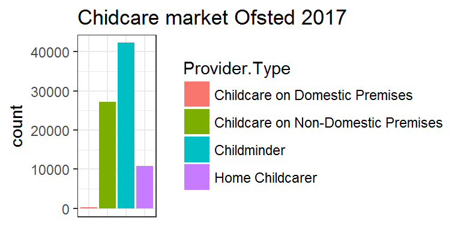

## Add another page

Adding another page is simple. You delineate as follows:

```r
Front Page
=============================================

Row
---------------------------------------------
### Chart 1

Row
---------------------------------------------

### Chart 2

Page 2
=============================================
```

## Insert a valuebox

You can insert a value box in a similar way to how you insert a chart

````
### My favourite number
```{r}
valueBox(10, icon = "fa-ceritifcate")
 ```
````

To customise the appareance and the icon:

````
  ```{r}
  most_places<- max(cc_data$Registered.places)
  valueBox(most_places, icon = "fa-bullhorn", color = "green")
  ```
````

The icon options are explained [here](https://rmarkdown.rstudio.com/flexdashboard/using.html#value_boxes)

## Insert a sidebar

You can insert a sidebar with additional information, notifications or links.

```r
Inputs {.sidebar}
-------------------------------------

**Contact**: kerry.cella@education.gov.uk

Row
-------------------------------------
```

You can also place shiny components inside:

```r
Inputs {.sidebar}
-------------------------------------

selectInput("la_choice", label = h3("Select LA"),
            choices = cc_data$Local.Authority, selected = "Barnet")
```

## Further information.

A more in depth guide to using flexdashboard is available from R Studio [here](https://rmarkdown.rstudio.com/flexdashboard/using.html)

Some examples of flexdashboards in action:

- Live CRAN package [downloads](https://jjallaire.shinyapps.io/shiny-crandash/)
- America's nucelar legacy with [leaflet](https://beta.rstudioconnect.com/jjallaire/htmlwidgets-waste-sites/htmlwidgets-waste-sites.html)

## General lesson learned

- Ask for feedback from your users as you build
- Do your data prep seperate from the markdown script.
- Print data separately used in graphs
- You might find it's the simplest features that offer most value
- R markdown / flex - great way to start learning html / css

## Who needs Shiny?

[**Crosstalk**](https://rstudio.github.io/crosstalk/)